# Daniel Fusca BCB420 Assignment 2

# About this notebook

This notebook calls the notebook for Assignment 1 as a child document, in order to run the necessary code to create my dataframe of normalized gene expression values. Since the Assignment 1 notebook is run, all text in this document is knit to HTML when the Assignment 2 notebook is compiled. This text is given in the section below. **To skip this Assignment 1 text and go to the actual work for Assignment 2, use the table of contents to go to the “Introduction to Assignment 2” section of this document.** Also note that this notebook (for Assignment 2) must be compiled in the same directory as my Assignment 1 notebook in order to compile properly. Some of the figures in this notebook are placed in the “Assignment_2_Figures” directory on my GitHub repository. This figure directory must be placed in the same directory as this R notebook in order for the notebook to compile properly. Finally, this notebook must be compiled in the same directory as the “420_Assignment_2.bib” file on my GitHub repository. Answers to questions given in the assignment are distributed throughout the notebook and are indicated in **bold**.

# Assignment 1 (full text)

## Introduction to dataset (Assignment 1)

(Note: answers to questions in the “Interpretation” section of the assignment are distributed throughout the notebook and indicated in **bold**)

The dataset that I have selected for this assignment has GEO accession number GSE125066 and can be found at [this URL.](https://www.ncbi.nlm.nih.gov/geo/query/acc.cgi?acc=GSE125066) The dataset is named “Effect of *Toxoplasma gondii* efector TgIST on global transcriptome of human foreskin fibroblasts (HFFs) upon type I IFN activation”, and comes from the 2019 paper “*Toxoplasma gondii* effector TgIST blocks type I interferon signaling to promote infection” by Matta et al., which can be found at [this URL.](https://www.pnas.org/content/116/35/17480) This experiment collected RNA-seq data from human foreskin fibroblasts (HFFs) in 6 different experimental groups. **Cells were either left uninfected, infected with wild-type *Toxoplasma gondii* (an intracellular parasite), or infected with knockout *T. gondii* missing a gene encoding a protein (TgIST) secreted during host infection. For each of these 3 infection treatments, human cells were either treated with IFN-B (a signalling molecule used to activate host defenses) or left untreated. So, there is 1 control condition (uninfected-untreated) and 5 different experimental conditions (uninfected & IFNB-treated, wild-type infected & untreated, wild-type infected & IFNB-treated, knockout-infected & untreated, and knockout-infected & IFNB-treated). Each of these 6 conditions was done in triplicate, for a total of 18 different replicates.**

**While there are lots of interesting comparisons I can make here, the one I’m most interested in is comparing uninfected human cells (control) to human cells infected with wild-type *T. gondii* (test condition), both without any IFN-B treatment. I spent a year doing a bioinformatics research project on *T. gondii*, but the focus of that project was genetic variation between *T. gondii* strains. So, I’m interested in *T. gondii*, but I’m not sure what kind of effect it has on humans when it actually infects them. *T. gondii* is known to manipulate its host cell to help its own survival, so I was curious to see what kind of gene expression changes might occur in cells infected with the parasite. I found this dataset with gene expression data for healthy human cells and cells infected with *T. gondii*, so I thought it would be interesting to compare these conditions and see what’s different.**

## Basic setup and data downloading (Assignment 1)

My pipeline here requires 5 different R packages: BiocManager, GEOquery, edgeR, biomaRt, and ggplot2. If these packages aren’t already installed, the code here installs them:

I now need to download the actual GEO dataset. Since downloading this dataset takes a bit of time, I don’t download the dataset if it’s already been downloaded. If the data hasn’t been downloaded yet, I use GEOquery to put all of the data into a directory called “GSE125066”:

I then load the downloaded gene expression data into R using read.csv:

## Initial cleaning of dataset (Assignment 1)

However, I’m only interested in the 18 columns giving raw gene expression counts for each gene (1 column for each replicate), along with the columns giving the Ensembl ID and name of each gene. So, I filtered this dataset to remove all of the columns I’m not interested in:

**In addition to the first column giving the name of each gene, this dataframe has 18 other columns corresponding to the 18 experimental replicates sequenced in this study:**

**Here, all of the replicates beginning with “UI” are human foreskin fibroblast cells that are uninfected with *T. gondii*, the replicates beginning with “RH” are infected with wild-type *T. gondii*, and the replicates beginning with “KO” are infected with mutant *T. gondii* parasites where one of the proteins secreted during infection is knocked out. Following these identifiers, the replicates named “UT” were not treated with IFN-B, and the replicates named “IFNB” were treated with IFN-B. Each of these 6 experimental combinations was done in triplicate, for a total of 18 different replicates.**

**For the purposes of my project, I only need to compare healthy control cells with a single experimental treatment. I’m interested in seeing which genes are differentially-expressed in human cells that are infected with wild-type *T. gondii*, so I want to compare uninfected, non-IFN-B treated cells (“UI_UT”) with wild-type infected, non IFN-B treated cells (“RH_UT”). When I’m doing my differential-expression analysis, I only want to look at the 6 replicates within this control and treatment group, but for the purposes of cleaning up my dataset, I think it makes sense to normalize and filter using all 18 replicates at the same time, since this data was collected, sequenced and processed with all replicates together. I can do my cleaning here using all 18 replicates, and then just filter the dataframe later to get the replicates that I’m interested in analyzing further.**

To make this processing easier, I should rename the columns that contain data for the 18 experimental replicates, so that they’re easier to read and identify:

The first column here contains the gene names included with the GEO dataset, and each of the 18 following columns gives expression data for one of the 18 experimental replicates.

Before I do any filtering or normalization, it would be good to know how many genes are in this initial dataset:

Knowing that every row contains a unique Ensembl ID (and so likely a unique gene, although I’ll have to check HUGO symbols to confirm this), I can next ask: does every gene in my dataset have some sort of expression value for each of the 18 replicates, or are there any missing or invalid values? I’m expecting all of my count data to be non-negative integers, so to confirm this I checked for any NA or negative values:

So, each of the 18 columns of this dataset that contain expression values only contain non-negative integer values, and none of them contain missing data in the form of NA values. This means there are no obvious technical errors that would require me to remove any rows from my dataset.

Now that I know there are no major issues with my expression data, I can start looking at how these expression values are distributed. For example, how many total counted reads are in each of the 18 replicates (i.e. what does each column sum to)?

So, there’s a lot of variation in the sequencing depth for each of these replicates (although these counts don’t include sequenced reads that weren’t mapped onto genes and used for counting). The total RNAs counted in each replicate range from 8,123,030 to 32,867,480, so it would be a good idea to normalize my counts for sequencing depth (e.g. using Counts Per Million).

Next, for each of the 18 replicates, as an overview I got the minimum, first quartile, median, mean, third quartile, and maximum expression values using the summary() function:

One conclusion to draw from these statistics is that all of the replicates have a median expression value of 0, meaning that at least half of the genes in each replicate did not have any detected expression at all.

As part of cleaning up this dataset, I should remove genes that have very low expression. As a first pass, I can look at how many genes had no detected expression in any of the replicates, as these are obviously genes that I would want to filter out.

For my project, I’m only really interested in the “UI_UT” data columns and the “RH_UT” data columns. How many genes had 0 detected expression in all 6 of these columns?

So, almost half the listed genes in this dataset had 0 detected expression across all 18 of the replicates I’m using here. Considering just the 6 replicates corresponding to the control and treament conditions I want to actually analyze, this percentage jumps to over 54%. Thus, there’s definitely a need for me to filter out lowly-expressed genes.

Each experimental condition has 3 replicates, so edgeR recommends only keeping genes expressed to at least 1 read per million in at least 3 of the replicates. The following code filters out all of the genes that do not meet this criteria:

How many genes are we left with after filtering out lowly-expressed genes?

**So, after filtering out 42,951 lowly-expressed genes, I’m left with 14,822 genes, which is around a quarter of the 57,773 genes that were present in the initial GEO dataset. Aside from these 42,951 “outliers” that I removed, I’m not going to exclude any other genes on the basis of their gene expression data. I don’t have any reason to suspect that any of these observations were the result of measurement error - all of the data here are non-negative integers, as expected of counts, and the distribution of expression values looked pretty normal to me.**

For each of the 18 replicates, get the minimum, first quartile, median, mean, third quartile, and maximum values of the remaining genes:

The medians and first quartiles of all 18 replicates are now well above 0, so it seems that the filtering here was able to successfully remove genes that were expressed at very low levels. However, the distribution of expression data appears to differ pretty substantially between the 18 replicates - the median values range from 148 to 477. Ideally, I want the distributions of expression values to be pretty similar to each other, so this is a sign that I should normalize my data. Before I do any normalization though, I should assign all of these genes HUGO symbols.

## Identifier mapping (Assignment 1)

For my final dataset, I want all of the rows of my dataframe (i.e. every different gene) to be named after the HUGO symbol for that gene, rather than its Ensembl ID as they are currently. Since I have a unique Ensembl ID for all of these genes, I can perform some identifier mapping to map these Ensembl IDs onto HUGO symbols, and then assign HUGO symbols to genes. To do this identifier mapping, I can use the biomaRt package to query Ensembl for the HUGO symbols corresponding to my Ensembl IDs.

This code is based off of the code presented in Lecture 4 of BCB420 for querying Biomart using the biomaRt package. Since retrieving this data from Ensembl can be slow, we only actually retrieve it the first time this code is run, after which we save it as an RData file. If we’ve run this code once already, we can just load the identifier mapping we saved previously:

I now have a dataframe with 2 columns: the first contains Ensembl IDs, and the second contains the HUGO symbol corresponding to that ID. First, I asked: how many rows are in the resulting Ensembl-HUGO identifier mapping?

Did any Ensembl IDs map onto more than 1 HUGO ID?

The Ensembl-HUGO mapping dataframe contains 14,472 Ensembl IDs in total, but only 14,471 unique Ensembl IDs. It looks like a single Ensembl ID mapped onto two different HUGO IDs (all other Ensembl IDs mapped to at most 1 HUGO symbol). To find which ID this is, I used the following command to count how many times each Ensembl ID appears in the Ensembl-HUGO mapping, and return the Ensembl IDs that appear more than once.

So, ENSG00000230417 mapped onto 2 different HUGO symbols:

Since my dataset of expression values from GEO has a column giving the name of each gene (in addition to its Ensembl ID), I can look up this Ensembl ID in my expression dataset to see what name was given to it:

So, the Ensembl ID “ENSG00000230417” mapped onto both “LINC00595” and “LINC00856”, but in the expression dataset it is only named as “LINC00856”. Also, none of the genes in the expression dataset were given the name “LINC00595”:

Since I can only assign 1 name to the row containing ENSG00000230417, I’m going to break the tie between its 2 mapped HUGO symbols by naming it LINC00856, as this is what it was already called in the GEO dataset. This is so that I’m consistent with my approach for giving names to Ensembl IDs that didn’t map to HUGO symbols, since in that case my only option is going to be to use the gene names already present in the GEO dataset.

Since I’m not using the mapping between ENSG00000230417 and LINC00595, I removed it from the Ensembl-HUGO mapping dataframe:

Next, I looked at how many rows in this dataframe did NOT map onto an empty HUGO symbol. This number gives the total number of unique Ensembl IDs in our filtered expression dataset that were able to map to a HUGO symbol (since after the above removal of LINC00595, no Ensembl ID maps to more than 1 HUGO ID)

Over 90% of the genes in my filtered dataset (13,815) were able to map onto a HUGO ID, which is pretty good. **However, there were 1007 Ensembl IDs (and therefore rows of expression values) that did NOT map onto any HUGO symbols (note that this mapping only used the 14,822 genes that passed my filter for lowly-expressed genes - when considering the full set of 57,773 genes initially in this dataset, it is likely that more than 1007 Ensembl IDs would have failed to map). For these 1007 genes, I’m going to have to set their HUGO symbol as the name that was given to them in the original GEO dataset.**

I then looked at another issue that could have arisen during mapping: did multiple different Ensembl IDs map to the same HUGO symbol? The code here gets all of the HUGO symbols that mapped with more than 1 Ensembl ID:

There appears to be 2 different values that appear more than one time in the “HUGO Symbol” column of the mapping. There’s an empty string that appears 656 times - these are Ensembl IDs that were unable to map onto any HUGO ID. The only actual HUGO ID that appears in this mapping more than 1 time is TUBB7P, which 2 different Ensembl IDs mapped onto:

It looks like both ENSG00000173876 and ENSG00000251297 mapped onto the same HUGO symbol, although these are the only genes to do so. I’m going to deal with this issue after I give HUGO symbols to the Ensembl IDs that didn’t map onto anything, since this process might create additional duplications.

I then added all of my HUGO symbols to my dataframe of gene expression values, based on the Ensembl ID that they mapped to:

Almost all (around 86%) of the genes in the filtered expression dataset had names that already matched the HUGO symbols I just assigned them. Out of the remaining 14% of genes, some genes will have different names because they didn’t map onto any HUGO symbol at all - as previously shown, there are 1007 of these genes. For these 1007 genes, I think it makes the most sense to give them the name that was already present in the GEO dataset. As shown above, the names in the dataset almost all matched the HUGO symbols I just assigned, so I’m reasonably confident that the names in the expression dataset right now are pretty accurate HUGO symbols. If I want to give names to the genes that didn’t map onto HUGO symbols, my best course of action is probably to fill in these missing values using the names already present in the dataset. I don’t really have an easy way of getting other names for these genes, so this seems like the best course of action.

The code below gets all of the genes that didn’t map to HUGO symbols, and assigns their HUGO symbol as the name already given in the GEO dataset:

The code above got rid of all of the genes with a HUGO symbol of "":

After filling in that missing information, how many genes still have HUGO symbols that don’t match the name given in the initial GEO dataset?

These 1053 genes are likely those that have outdated annotations compared to what’s currently on Ensembl, so in these cases I think it makes the most sense to ignore the names that were initially in the GEO dataset and use the HUGO symbols I just mapped for them.

Before I finish with my identifier mapping and move on to normalization, I still need to address the genes where 2 different Ensembl IDs mapped onto the same HUGO symbol. I previously identified the TUBB7P gene as being problematic in this regard, but filling in missing HUGO IDs using the names in the GEO dataset created an additional 8 cases of this issue:

**There are now 9 HUGO symbols (ACBD6, AGAP9, C17orf100, CBWD6, MEG8, NBPF20, RPS17, TUBB7P, and ZCCHC3) that each map onto 2 different Ensembl IDs:**

**Thus, right now in my dataset there are 18 rows of expression values that belong to only 9 different genes, based on HUGO symbols. I think the fairest way to resolve these conflicts is, for each replicate, to add together the counts for each pair of identical HUGO symbols. The only other option would be to completely ignore one of the “duplicate” genes in each pair, but the issue with that is I don’t really have a good way of deciding which gene within each pair to ignore, and which to keep. So, in order to not ignore any reads that appear to map onto genes, I’m going to combine the counts within each pair by adding them up, for each of the 18 replicates.**

How many genes are we now left with in our expression dataset after merging these 9 pairs of rows?

This is 9 fewer genes than I had before (14,822), which is as expected since I should have only removed 9 rows from my dataframe.

After merging those 9 pairs of rows, every gene in this dataset now has a unique HUGO symbol:

Now, I can set the row names of my expression dataframe to be HUGO symbols instead of Ensembl IDs, and then remove all of the columns from my dataframe that aren’t the 18 columns of expression values:

If I did everything correctly, I should now have a dataframe with 14,813 rows (one for each gene) and 18 columns (1 for each replicate):

## Normalization (Assignment 1)

My final major step here is to normalize my expression dataset. As I found previously, the replicates here vary quite a bit in the depth they were sequenced to. To account for this, I can normalize my data by taking the log2 of the Count Per Million (CPM) for each expression value, using Trimmed Mean of M-values (TMM) normalization. This should correct for the technical variation present in this data.

The code here performs the log-CPM and TMM normalization on my data. For comparison purposes, I calculated log-CPM values both with and without TMM normalization. This code is based off of the normalization code presented in Lecture 4 of BCB420.

## Output final dataset (Assignment 1)

Now that all of my cleaning and normalization are done, I can export my finalized dataframe. Again, here are the dimensions of this dataframe:

For future use with the rest of my project, I should export this expression dataframe onto my computer. First, I saved this dataset as an RData object named “logCPMNormalizedExpressionData.RData”

Whenever I need this dataframe, I can just load it into R using the load() function.

Additionally, I also saved this same dataset as a CSV file, in case I want it in a format that I can actually read or use outside of R:

To summarize, this notebook outputs 2 different objects for future use: a dataframe of cleaned and normalized gene counts as an RData file (logCPMNormalizedExpressionData.RData), and the exact same dataframe as a CSV file (logCPMNormalizedExpressionData.csv).

# Introduction to Assignment 2

The goal of this project is to determine which genes are differentially-expressed in human cells infected with the intracellular parasite *Toxoplasma gondii*, and to look for any biological patterns in these differentially-expressed genes. To do this, I am using a gene expression dataset from the 2019 paper “*Toxoplasma gondii* effector TgIST blocks type I interferon signaling to promote infection” (Matta et al. 2019), which can be found at [this URL.](https://www.pnas.org/content/116/35/17480) In this study, human foreskin fibroblast (HFF) cells were either left uninfected, infected with wild-type *T. gondii* (from the RH strain), or infected with knockout *T. gondii* missing a gene encoding a protein called TgIST that the parasite secretes during host infection. For each of these 3 infection conditions, the authors additionally treated HFF cells with the signaling molecule IFN-B, which is involved in the response of host cells to infection, or left them untreated. So, there is 1 control condition (uninfected & untreated) and 5 different experimental conditions (uninfected & IFN-B-treated, wild-type infected & untreated, wild-type infected & IFN-B-treated, knockout-infected & untreated, and knockout-infected & IFN-B-treated). RNA-seq data was collected from each of these 6 experimental conditions in triplicate, for a total of 18 different RNA-seq replicates. This RNA-seq data is deposited in GEO at accession number GSE125066, which can be found at [this URL.](https://www.ncbi.nlm.nih.gov/geo/query/acc.cgi?acc=GSE125066)

The authors’ major findings with regard to gene expression are shown in the volcano plots below, which come from Figure 2 of their paper (Matta et al. 2019).The genes indicated in blue are signaling genes used to activate host defenses against infection. This study found that these genes are activated by IFN-B (panel A), but repressed in IFN-B-treated cells that are also infected with wild-type *T. gondii* (panel B), suggesting that *T. gondii* alters host gene expression for its own benefit. The authors determined that TgIST plays a role in this host manipulation, as infection with knockout parasites missing this gene still results in the IFN-B-mediated upregulation of these signaling genes, as seen in uninfected cells (panel C).

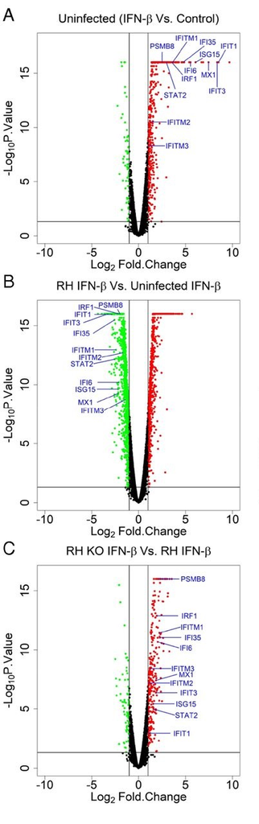

**(Figure 2 from Matta et al. (2019))**

While the comparisons done in this study all involve IFN-B-treated cells, my comparison here will be between untreated cells. So, my control condition is uninfected HFF cells untreated with IFN-B, and my experimental condition is wild-type *T. gondii*-infected HFF cells untreated with IFN-B.

In Assignment 1, I downloaded the raw gene expression data for these 18 replicates off of GEO, filtered out lowly-expressed genes (those without at least 1 Count Per Million in at least 3 different replicates), and mapped their Ensembl IDs onto HUGO gene symbols. Doing so reduced my initial dataset of 57,773 genes down to 14,813 genes with unique HUGO symbols. I then normalized this raw data to log2-Counts Per Million (CPM) using Trimmed Mean of M-values (TMM) normalization, to account for technical variation between samples. Doing so produced a dataframe of log2-CPM normalized gene expression values with 14,813 rows (one for each gene) and 18 columns (one for each replicate). Each of these rows is named after a unique HUGO gene symbol. I can now use this gene expression data to detect genes that are differentially-expressed between uninfected, untreated HFF cells and wild-type infected, untreated HFF cells.

# Initial setup

Before I continue with my analysis pipeline, I need to make sure that all of the packages I need are properly loaded. The code here checks to see if the packages I need are properly installed, and installs them if necessary. The packages I use in this notebook are BiocManager (Morgan 2019), limma (Ritchie et al. 2015), and ComplexHeatmap (Gu, Eils, and Schlesner 2016). While they’re not explicitly used in this notebook, I also make use of several packages during Assignment 1 (which is sourced to generate the gene expression data here), namely GEOquery (Davis and Meltzer 2007), edgeR (McCarthy, Chen, and Smyth 2012), biomaRt (Durinck et al. 2005), and ggplot2 (Wickham 2016).

```r
if (!requireNamespace("BiocManager", quietly = TRUE))
    install.packages("BiocManager")

if (!requireNamespace("limma", quietly = TRUE))
    BiocManager::install("limma")

if (!requireNamespace("ComplexHeatmap", quietly = TRUE))
    BiocManager::install("ComplexHeatmap")
```

# Differential expression analysis

Right now, my dataframe of gene expression values contains one column for each of the 18 replicates in the original study. I’m only interested in 2 of the 6 experimental groups from this study, so I only need 6 of the 18 replicates. The code here filters my dataframe from Assignment 1 to keep only the data from uninfected, untreated cells and wild-type infected, untreated cells.

```r
replicateNames <- colnames(logCPMNormalizedExpressionData)[grepl(
            "UI_UT", colnames(logCPMNormalizedExpressionData)) | grepl(
            "RH_UT", colnames(logCPMNormalizedExpressionData))]
expressionData <- logCPMNormalizedExpressionData[ , replicateNames]
```

Here’s what the dataset now looks like - the “UI_UT” columns are the 3 uninfected replicates, and the “RH_UT” columns are the 3 infected replicates:

```r
head(expressionData)
```

```
##          UI_UT_RepA UI_UT_RepB UI_UT_RepC RH_UT_RepA RH_UT_RepB RH_UT_RepC
## TSPAN6     3.792151   3.213486   3.728097   3.623227   3.692401   3.503423
## DPM1       4.712662   4.713156   4.793922   4.170228   4.315122   4.252736
## SCYL3      2.613111   2.175867   2.840798   2.373670   2.001784   2.007856
## C1orf112   1.773581   1.948842   1.567280   2.476757   2.730322   2.678423
## CFH        5.862165   4.796965   5.278425   5.719881   5.530343   5.591072
## FUCA2      5.690473   6.165490   6.060852   5.848472   6.281509   6.194031
```

In order to perform differential gene expression, I need to define a model to fit my data to. To figure out a good model design, I can make an MDS plot of these 6 replicates to see how different replicates cluster together:

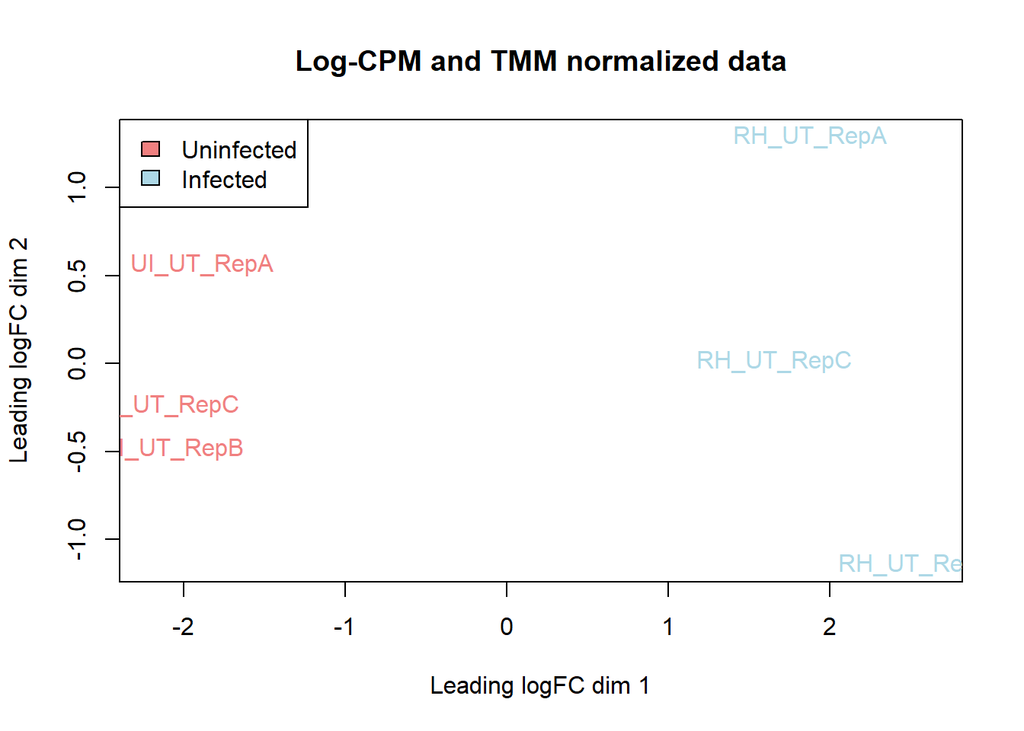

```r
limma::plotMDS(expressionData, col = rep(c("lightcoral", "lightblue"), each = 3),
               main = "Log-CPM and TMM normalized data")

# Add in a plot legend since plotMDS doesn't include one
legend("topleft", legend = c("Uninfected", "Infected"), fill = c("lightcoral",
                                                                 "lightblue"))
```

The uninfected and infected replicates are clearly separated from each other, so infection status has a significant effect on gene expression similarity. Also, the replicates appear to separate out along the y-axis by the batch they were sequenced in (either “A”, “B”, or “C”). So, my model should take into account differences in both infection status and sequencing batch, so I can look for differences due to infection while controlling for differences due to sequencing batch.

To detect differentially-expressed genes, I’m going to use limma (Ritchie et al. 2015). The first step is to define a model to use for differential expression. Here, I make an object to classify the infection status and sequencing batch of each of the 6 replicates, since I want my model to include both infection and batch information. This code is based off of code shown in Lecture 5:

```r
replicateLabels <- data.frame(Infection = rep(c("Uninfected", "Infected"), each = 3),
                              Batch = rep(c("A", "B", "C"), times = 2))
rownames(replicateLabels) <- colnames(expressionData)

# Make infection status an ordered factor with "Uninfected" first so that Uninfected
# expression data is the baseline for differential-expression analysis (otherwise
# Infected will be treated as the baseline)
replicateLabels$Infection <- factor(replicateLabels$Infection, levels = c("Uninfected", "Infected"))

replicateLabels
```

|  | Infection | Batch |
| --- | --- | --- |
| UI_UT_RepA | Uninfected | A |
| UI_UT_RepB | Uninfected | B |
| UI_UT_RepC | Uninfected | C |
| RH_UT_RepA | Infected | A |
| RH_UT_RepB | Infected | B |
| RH_UT_RepC | Infected | C |

I can now use these replicate labels to create a model using model.matrix():

```r
expression_model <- model.matrix(~ replicateLabels$Infection + replicateLabels$Batch)

expression_model
```

```
##   (Intercept) replicateLabels$InfectionInfected replicateLabels$BatchB
## 1           1                                 0                      0
## 2           1                                 0                      1
## 3           1                                 0                      0
## 4           1                                 1                      0
## 5           1                                 1                      1
## 6           1                                 1                      0
##   replicateLabels$BatchC
## 1                      0
## 2                      0
## 3                      1
## 4                      0
## 5                      0
## 6                      1
## attr(,"assign")
## [1] 0 1 2 2
## attr(,"contrasts")
## attr(,"contrasts")$`replicateLabels$Infection`
## [1] "contr.treatment"
##
## attr(,"contrasts")$`replicateLabels$Batch`
## [1] "contr.treatment"
```

The first 3 replicates (i.e. the uninfected ones) have their infection status in the second column set to 0, so the uninfected data should be treated as the control in differential-expression analyses.

Now that I have a model, I can fit my data to the model and calculate differential expression using limma (Ritchie et al. 2015). Again, this code is based off of code shown in Lecture 5. For the eBayes() function, I set “trend = TRUE” to indicate that this is RNA-seq and not microarray data. For the topTable() function I set the “coef” parameter to 2, since in my model object (expression_model), expression status is represented in the second column (“replicateLabels$InfectionInfected”).

```r
model_fit <- limma::lmFit(expressionData, expression_model)
bayes_model_fit <- limma::eBayes(model_fit, trend = TRUE)
differential_expression_results <- limma::topTable(bayes_model_fit, coef = 2,
                          adjust.method = "BH", number = nrow(expressionData))
```

I now have an object that contains the results of differential-expression analysis between wild-type *T. gondii*-infected HFF cells and uninfected HFF cells, for all 14,813 of my genes. Here’s what the resulting object looks like:

```r
head(differential_expression_results)
```

|  | logFC | AveExpr | t | P.Value | adj.P.Val | B |
| --- | --- | --- | --- | --- | --- | --- |
| SLCO2A1 | 4.746237 | 5.256838 | 48.21429 | 4.433024e-09 | 3.210282e-05 | 11.45677 |
| GPR183 | 6.512744 | 3.220799 | 43.49453 | 8.273854e-09 | 3.210282e-05 | 11.00522 |
| TMEM97 | 4.528273 | 5.354024 | 41.86469 | 1.042653e-08 | 3.210282e-05 | 10.82911 |
| MCM4 | 2.843788 | 6.545295 | 40.22986 | 1.326973e-08 | 3.210282e-05 | 10.64061 |
| C17orf58 | 4.524287 | 4.331088 | 39.36082 | 1.514485e-08 | 3.210282e-05 | 10.53523 |
| TYMS | 3.143048 | 5.831349 | 39.35671 | 1.515442e-08 | 3.210282e-05 | 10.53472 |

For every gene, I have the log-fold change and average expression, along with p-values and adjusted p-values. **I corrected p-values using Benjamini-Hochberg correction, since this method is commonly used to correct for multiple hypothesis testing, and this was the correction method we used in class and on the homework assignments.**

I now need to filter these genes to get only those that are significantly differentially-expressed. **For my significance threshold, I’m going to use a p-value of 0.05, again because this is a commonly-used statistical threshold, and the one that was used in class and on the homework assignments.**

Without any correction for multiple hypothesis testing (i.e. using non-adjusted p-values), how many genes had a p-value of at most 0.05?

```r
sum(differential_expression_results$P.Value <= 0.05)
```

```
## [1] 9523
```

After correcting for multiple hypothesis testing using Benjamini-Hochberg correction, how many genes have an adjusted p-value of at most 0.05?

```r
sum(differential_expression_results$adj.P.Val <= 0.05)
```

```
## [1] 8810
```

**So, using a p-value threshold of 0.05, there are 9523 significant genes using normal p-values and 8810 significant genes using adjusted p-values**. Since I do want to correct for multiple hypothesis testing, I’m only going to look at these 8810 genes that pass my adjusted p-value cutoff. What proportion of my 14,813 genes is this?

```r
sum(differential_expression_results$adj.P.Val <= 0.05) / nrow(expressionData)
```

```
## [1] 0.5947479
```

So, using an adjusted p-value cutoff of 0.05, almost 60% of the genes in my dataset come out as significantly differentially-expressed. This is kind of a lot of genes, and I’m not sure how informative such a large group of genes is going to be. I can narrow down these results by applying an additional threshold on the magnitude of expression differences, rather than just their statistical significance. **As an additional threshold, I’m only going to consider genes to be significantly differentially-expressed if they have a magnitude of log-fold change of at least 1 (i.e. they at least double or halve in expression between infected and uninfected cells).** I think it makes sense to filter genes based on the magnitude of differences - the study I got this data from (Matta et al. 2019) also filtered their differentially-expressed genes using a log-fold change cutoff of 1, and I’ve seen this threshold used in many other papers using RNA-seq data. This threshold should help me to narrow down my set of genes to only my strongest and most biologically relevant hits.

Here’s how many genes are significant using a non-adjusted p-value cutoff of 0.05 and a magnitude of log-fold change cutoff of at least 1:

```r
sum(differential_expression_results$P.Value <= 0.05 &
      abs(differential_expression_results$logFC) >= 1)
```

```
## [1] 3603
```

And here’s how many genes are significant using an adjusted p-value cutoff of 0.05 and a magnitude of log-fold change cutoff of at least 1:

```r
sum(differential_expression_results$adj.P.Val <= 0.05 &
      abs(differential_expression_results$logFC) >= 1)
```

```
## [1] 3546
```

**So, using a significance threshold of 0.05 and a log-fold change cutoff of at least 1 (or below -1), there are 3603 differentially-expressed genes using non-adjusted p-values and 3546 differentially-expressed genes using adjusted p-values. For my final set of differentially-expressed genes, I’m going to use the 3546 genes with an adjusted p-value of at most 0.05 and a magnitude of log-fold change of at least 1.**

I then checked what proportion of my initial 14,813 genes are in this set of differentially-expressed genes:

```r
sum(differential_expression_results$adj.P.Val <= 0.05 &
      abs(differential_expression_results$logFC) >= 1) / nrow(expressionData)
```

```
## [1] 0.2393843
```

So, around 24% of my genes pass my statistical significance and log-fold change thresholds.

To visualize the amount of differential expression in my set of 14.813 genes, I made an MA plot using the results calculated by limma. On this plot, I color-coded my genes according to whether they were significantly upregulated (adjusted p-value <= 0.05, log-fold change >= 1), significantly downregulated (adjusted p-value <= 0.05, log-fold change <= -1), or not significantly different.

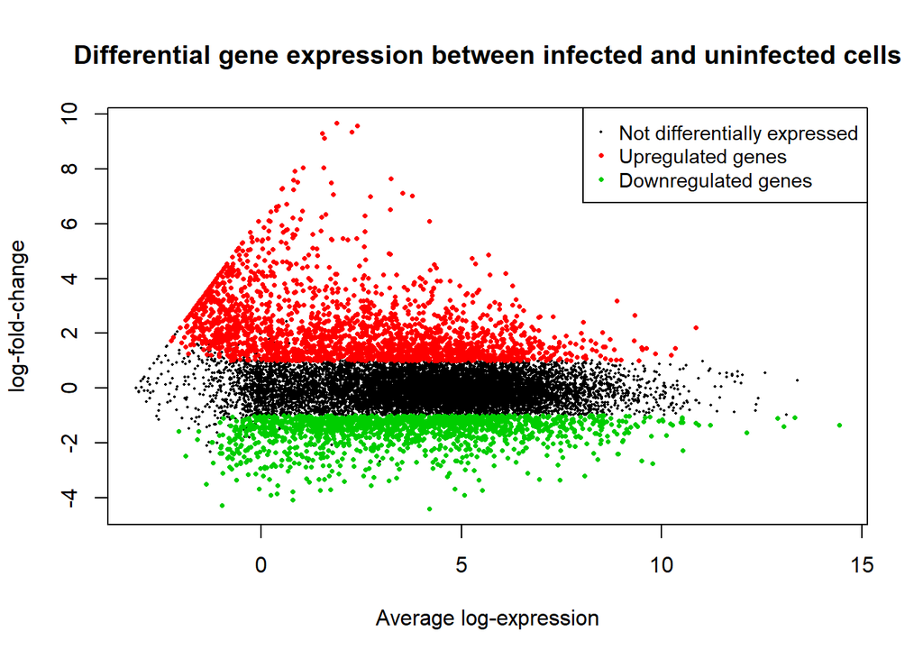

```r
# Reorder the dataframe of log-fold changes and p-values so that the rows match
# the original dataset
differential_expression_results <- differential_expression_results[rownames(expressionData), ]

# Classify the differential-expression status of each gene
differential_expression_status <- apply(differential_expression_results, 1, function(gene) {
  if (gene["logFC"] <= -1 && gene["adj.P.Val"] <= 0.05) {
    return("Downregulated genes")
  } else if (gene["logFC"] >= 1 && gene["adj.P.Val"] <= 0.05) {
    return("Upregulated genes")
  } else {
    return("Not differentially expressed")
  }
})

# Draw the resulting MA plot
limma::plotMD(bayes_model_fit, column = 2, status = differential_expression_status,
              cex = 0.5, main = "Differential gene expression between infected and uninfected cells")
```

Based on this MA plot, it appears that I have more upregulated genes than downregulated genes, and that the highest log-fold changes are found among my upregulated genes.

Now that I have a list of differentially-expressed genes, I can define subsets of these genes, based on the direction of change. The code here splits my dataframe of log-CPM expression values into only the genes that are significantly upregulated, only the genes that are significantly downregulated, and the union of these sets (i.e. the genes that are significantly different in either direction).

```r
up_genes <- rownames(differential_expression_results)[differential_expression_results$logFC >= 1
                            & differential_expression_results$adj.P.Val <= 0.05]
up_genes <- expressionData[up_genes, ]

down_genes <- rownames(differential_expression_results)[differential_expression_results$logFC <= -1
                            & differential_expression_results$adj.P.Val <= 0.05]
down_genes <- expressionData[down_genes, ]

diff_genes <- rbind(up_genes, down_genes)
```

I now have a set of upregulated genes (up_genes), a set of downregulated genes (down_genes), and a set of both upregulated and downregulated genes (diff_genes).

How many genes are significantly upregulated and pass my thresholds?

```r
nrow(up_genes)
```

```
## [1] 2101
```

How many genes are significantly downregulated and pass my thresholds?

```r
nrow(down_genes)
```

```
## [1] 1445
```

**So, of my 3546 differentially-expressed genes, 2101 are significantly upregulated in infected cells, and 1445 are significantly downregulated in infected cells**.

Here are the expression values for the 10 most significant genes that are overexpressed in infected cells (using a log-fold change cutoff of 1):

```r
sorted_differential_expression_results <- differential_expression_results[order(
                   differential_expression_results$adj.P.Val, decreasing = F), ]
most_significant_up_genes <- rownames(sorted_differential_expression_results[
                    sorted_differential_expression_results$logFC >= 1, ])[1:10]
expressionData[most_significant_up_genes, ]
```

```
##          UI_UT_RepA UI_UT_RepB UI_UT_RepC RH_UT_RepA RH_UT_RepB RH_UT_RepC
## MCM4      5.1144124  5.2697429  4.9860474   7.993942   8.083383   7.824242
## TMEM97    3.4155685  2.8380001  3.0160934   7.766654   7.621136   7.466692
## ACAT2     3.6696173  3.4722079  3.6194654   6.995030   7.019314   6.914419
## SLC39A8   2.6598439  2.6058441  3.0033399   6.493363   6.706583   6.797580
## GPR183    0.3604519  0.2367365 -0.7039080   6.661442   6.673013   6.097057
## CCL11    -1.3308863 -3.1138090 -2.7262591   7.553261   6.930102   7.073890
## SLCO2A1   2.5249751  3.2291439  2.8970380   7.348307   7.772971   7.768591
## TYMS      4.0348569  4.6793598  4.0652575   7.250591   7.716810   7.241218
## C17orf58  1.8561681  2.1265574  2.2241071   6.420236   6.827761   6.531698
## FAM111B   1.2211212  1.7019156  0.5541349   6.895277   7.808006   7.026978
```

And here are the expression values for the 10 most significant genes that are underexpressed in infected cells (using a log-fold change cutoff of -1):

```r
most_significant_down_genes <- rownames(sorted_differential_expression_results[
                    sorted_differential_expression_results$logFC <= -1, ])[1:10]
expressionData[most_significant_down_genes, ]
```

```
##         UI_UT_RepA UI_UT_RepB UI_UT_RepC RH_UT_RepA RH_UT_RepB RH_UT_RepC
## SPOCD1    7.292318   7.498595   7.466800   5.069910   5.306766   5.174947
## MALL      7.495038   7.503834   7.136446   3.937034   3.501596   3.509124
## ATP10D    6.627871   6.587559   6.692433   4.188567   4.110595   4.143355
## DKK1      8.552845   8.189987   8.340313   6.301684   5.548088   5.885440
## SYPL2     7.221648   6.848025   7.268222   4.218624   3.229822   3.856349
## GBP1      5.510931   5.872086   6.008363   2.947874   3.022043   3.119600
## TPD52L1   5.409288   6.232083   6.031317   2.748043   3.176057   3.241043
## CRYAB     6.025428   6.925150   6.781494   3.368268   3.754860   3.700650
## WFDC1     5.911278   6.497498   6.419357   3.017918   3.157681   2.937112
## PRSS12    8.334005   7.721490   8.137860   6.457263   5.530343   6.127025
```

As expected, the upregulated genes have higher expression in infected (“RH”) replicates than uninfected (“UI”) ones, whereas the downregulated genes have lower expression in infected replicates.

In order to visualize the expression changes among all of my differentially-expressed genes, I made heatmaps of log-CPM normalized gene expression values using ComplexHeatmap (Gu, Eils, and Schlesner 2016). I also applied row normaliztion using scale() to each gene, to better visualize differences between replicates. These heatmaps cluster rows and columns together on the basis of similar expression patterns.

Here’s the heatmap of the expression values for all 3546 differentially-expressed genes between infected and uninfected cells:

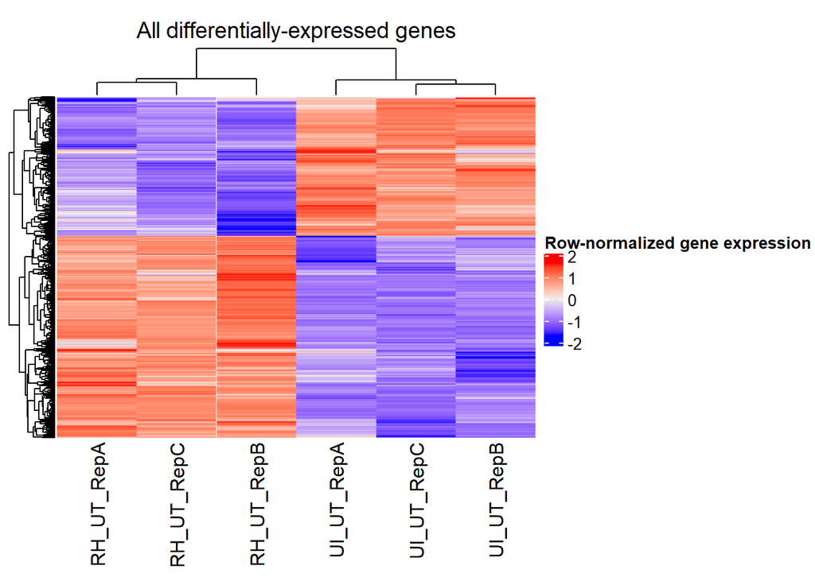

```r
ComplexHeatmap::Heatmap(t(scale(t(diff_genes))), show_row_names = FALSE,
                        column_title = "All differentially-expressed genes",
                        name = "Row-normalized gene expression")
```

Here’s the heatmap of the expression values for the 2101 genes that are significantly upregulated in infected cells:

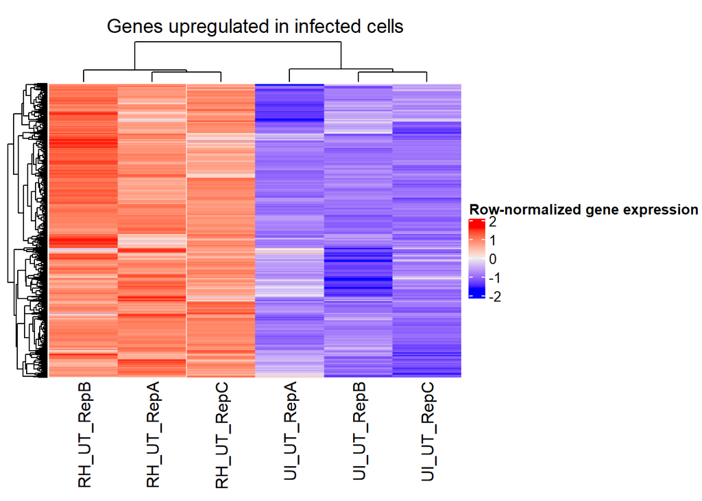

```r
ComplexHeatmap::Heatmap(t(scale(t(up_genes))), show_row_names = FALSE,
                        column_title = "Genes upregulated in infected cells",
                        name = "Row-normalized gene expression")
```

And here’s the heatmap of the expression values for the 1445 genes that are significantly downregulated in infected cells:

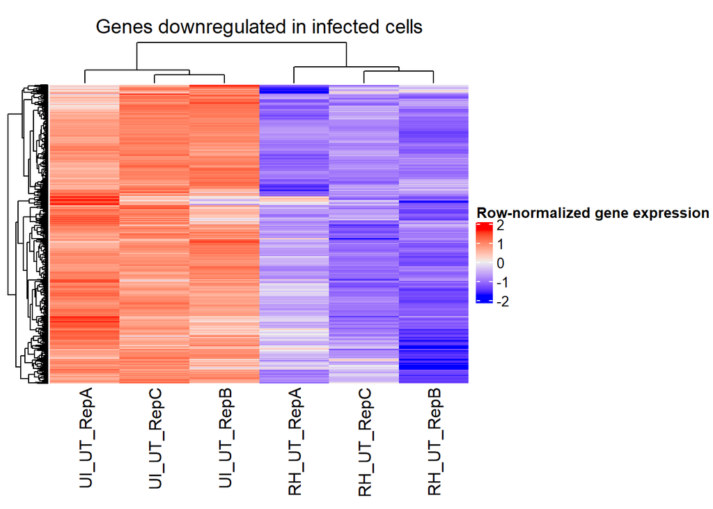

```r
ComplexHeatmap::Heatmap(t(scale(t(down_genes))), show_row_names = FALSE,
                        column_title = "Genes downregulated in infected cells",
                        name = "Row-normalized gene expression")
```

**In all of these 3 heatmaps, the 3 replicates within each experimental treatment very strongly cluster together (based on the dendrogram above each heatmap), and the differences in expression between infected and uninfected cells are very noticeable. It makes sense that I have such strong clustering - this clustering is consistent with the MDS plots I made previously, and biologically, the variation between cell cultures from the same line and same treatment conditions is expected to be much less than the variation due to infection with an intracellular parasite like *T. gondii*.**

# Overrepresentation analysis

Now that I have my sets of upregulated and downregulated genes (along with their union, which are differentially-expressed in either direction), I can perform thresholded overrepresentation analysis to see if there any annotated gene sets that are enriched for my genes here.

**To run my thresholded gene set enrichment analysis, I’m going to use g:Profiler (Reimand et al. 2007) and its web interface [found at this URL](https://biit.cs.ut.ee/gprofiler/gost). I’m using g:Profiler because I already have experience using this tool (I used it in one of the homework assignments for this class), and I’ve found that it’s very straighforward to use, and the resulting visualizations are a lot cleaner and easier to interpret compared to some other overrepresentation tools I’ve seen.**

Since I’m using g:Profiler through its website, I need to export my lists of differentially-expressed genes so I can upload them to g:Profiler’s website. This is the code I used to write my upregulated, downregulated, and differentially-expressed (in either direction) genes to text files:

```r
write.table(rownames(up_genes), file = "up_genes.txt", quote = F, row.names = F, col.names = F)
write.table(rownames(down_genes), file = "down_genes.txt", quote = F, row.names = F, col.names = F)
write.table(rownames(diff_genes), file = "diff_genes.txt", quote = F, row.names = F, col.names = F)
```

I then ran g:Profiler 3 times - once for each of these sets of genes. For each run of g:Profiler I set the “Organism” option to “Homo sapiens”. **I ran g:Profiler with a significance threshold of 0.05 using Benjamini-Hochberg correction, for the same reasons outlined for my differential expression analyses. For each run of g:Profiler I used 4 differnent sets of gene annotations: GO biological process, KEGG, Reactome, and WikiPathways. I used this annotation data because I’m interested in the broad biological pathways that are affected by *T. gondii* infection, and these annotation sets are designed to carry pathway information, whereas annotations like GO molecular function and GO cellular component are harder to associate with actual pathways.**

**The versions of these 4 annotation sets that I used are as follows (this information comes from g:Profiler’s “Data sources” tab):**

**GO biological process – releases/2019-07-01**

**KEGG – KEGG FTP Release 2019-09-30**

**Reactome – annotations: ensembl classes: 2019-10-2**

**WikiPathways – 20190910**

For genes with mulitple Ensembl IDs, I selected the ID that had the most GO annotations. I did not apply any cutoffs to the size of the returned genesets (except in 1 case, which is indicated below). My results from running g:Profiler on these 3 sets of genes are shown below, split into 3 main sections (upregulated genes, downregulated genes, and both up- and downregulated genes together).

### Upregulated genes only

**In total, the 2101 genes upregulated in infected cells were enriched for 804 GO biological process terms, 30 KEGG terms, 131 Reactome terms, and 26 WikiPathways terms.** The distribution of significance values for all of these terms is plotted below. Each point is a different term, and height above the x-axis indicates statistical significance. On the x-axis, “GO:BP” stands for GO biological process, “REAC”, stands for Reactome, and “WP” stands for WikiPathways (“KEGG” is just KEGG). This plot was generated by g:Profiler.

[figure not shown]

In addition to this plot, g:Profiler also returned statistics for all of the significant terms. These include the adjusted p-values (“padj”), the total number of human genes within this term (“T”), the number of queried genes annotated with any term in the annotation dataset (“Q”), and the number of queried genes within this specific term (“T AND Q”). For all 3 sets of queried genes, I took a screenshot of the 20 most statistically significant returned genesets in each of the 4 annotation categories.

Here are the 20 most significant GO biological process terms among upregulated genes:

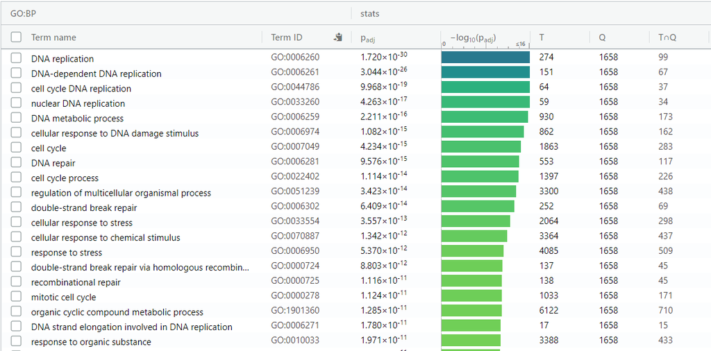

Here are the 20 most significant KEGG terms among upregulated genes:

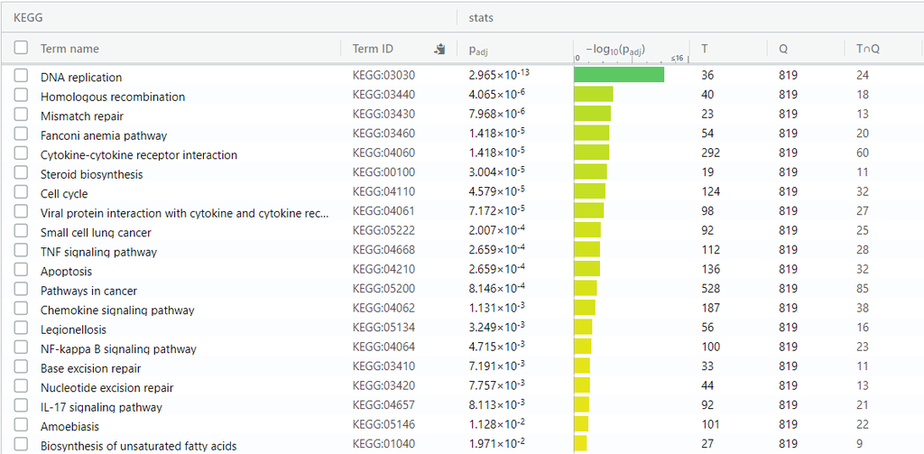

Here are the 20 most significant Reactome terms among upregulated genes:

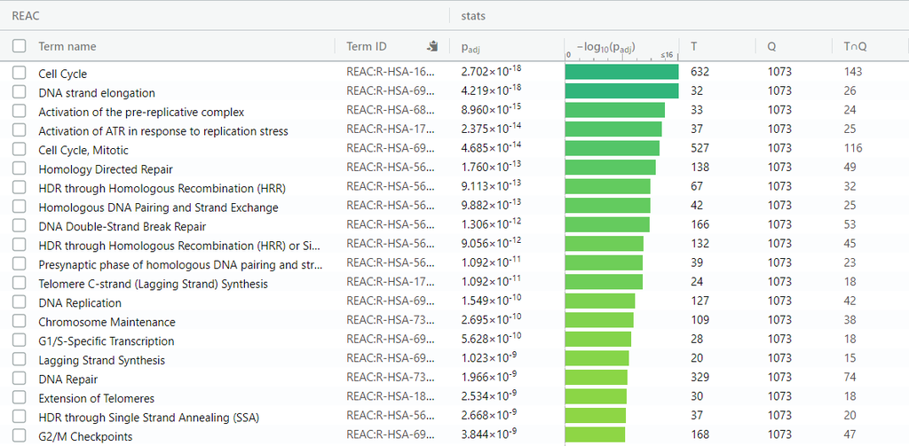

And here are the 20 most significant WikiPathways terms among upregulated genes:

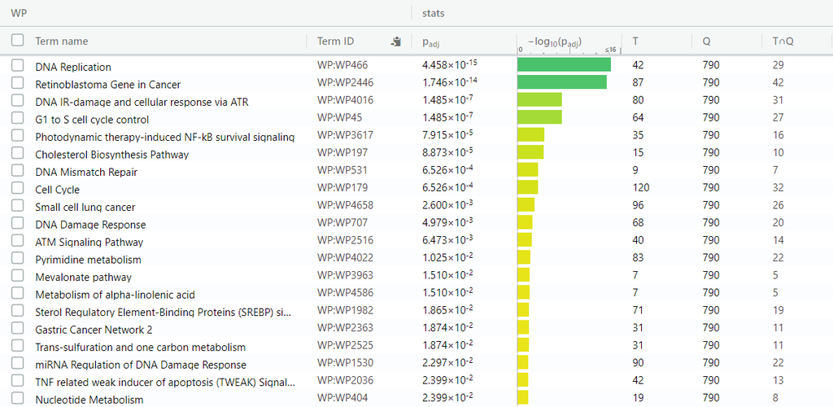

Overall, it looks like the dominant themes among these upregulated genes have to do with DNA replication, DNA repair, and regulation of the cell cycle.

### Downregulated genes only

**In total, the 1445 genes downregulated in infected cells were enriched for 410 GO biological process terms, 30 KEGG terms, 9 Reactome terms, and 4 WikiPathways terms.** The distribution of significance values for all of these terms is plotted below, using the same annotation abbreviations as the previous plot.

[figure not shown]

Here are the 20 most significant GO biological process terms among downregulated genes:

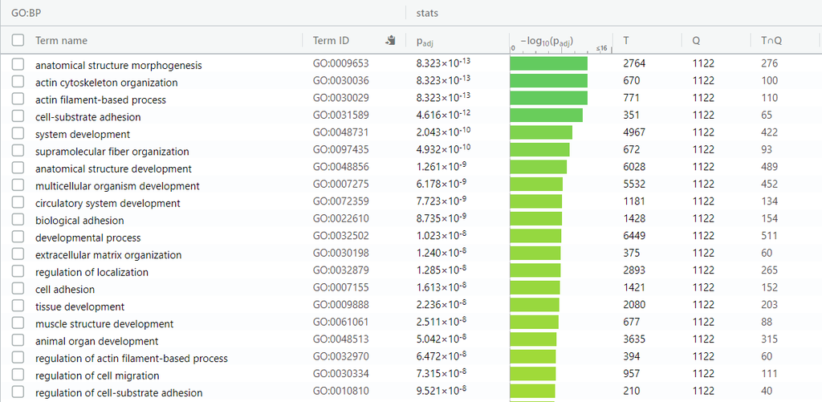

Here are the 20 most significant KEGG terms among downregulated genes:

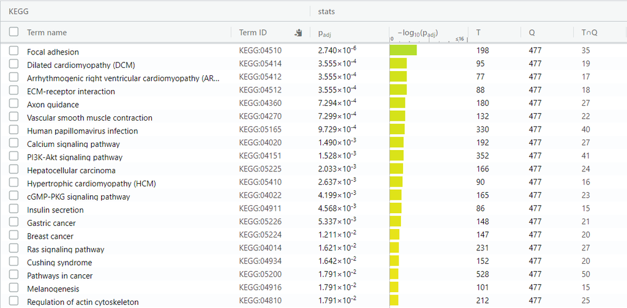

Here are all 9 significant Reactome terms among downregulated genes:

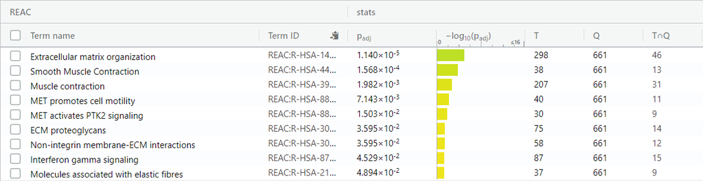

And here are all 4 significant WikiPathways terms among downregulated genes:

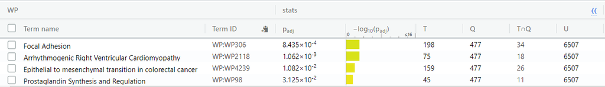

Overall, it looks like the dominant themes among these downregulated genes have to do with cell adhesion, the extracellular matrix, and cytoskeleton organization.

### Both upregulated and downregulated genes together

**In total, the 3546 genes that are differentially-expressed (either up or down) in infected cells were enriched for 1012 GO biological process terms, 51 KEGG terms, 120 Reactome terms, and 15 WikiPathways terms. This is more GO biological process terms and KEGG terms than were returned for either the upregulated or downregulated genes individually, but I now have fewer Reactome terms and WikiPathways terms than I got from just my upregulated genes.** The distribution of significance values for all of these terms is plotted below, using the same annotation abbreviations as the previous plots.

[figure not shown]

Here are the 20 most significant GO biological process terms among all differentially-expressed genes:

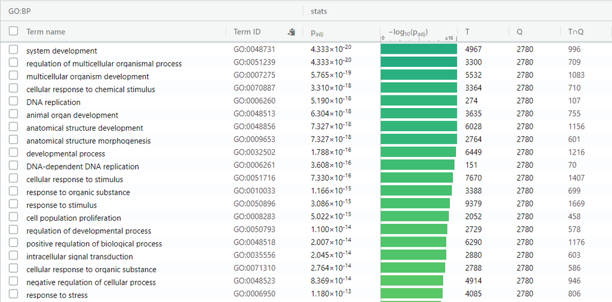

Here are the 20 most significant KEGG terms among all differentially-expressed genes:

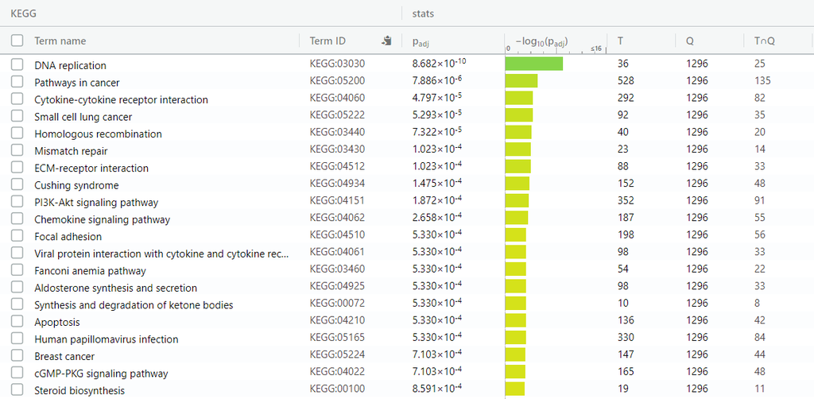

Here are the 20 most significant Reactome terms among all differentially-expressed genes:

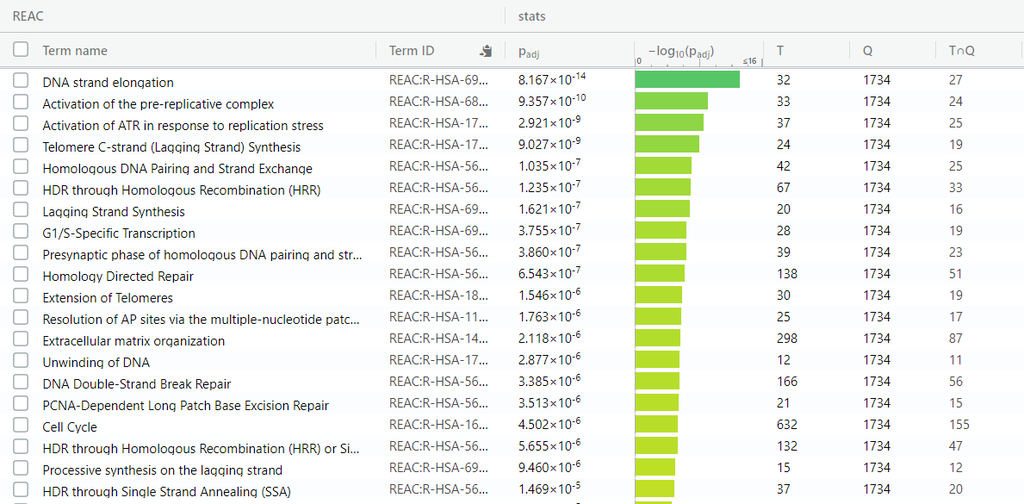

And here are all 15 WikiPathways terms among all differentially-expressed genes:

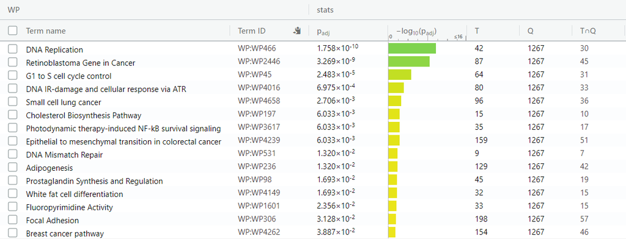

Many of the most significant GO biological process terms enriched among the set of all differentially-expressed genes are very general and contain thousands of different genes. To get a look at the more specific GO biological process terms enriched among these genes, I restricted the returned genesets to only those that contained at most 1000 genes. Doing so reduced the total number of enriched GO BP terms from 1012 to 820. The 20 most significant of these 820 terms are shown below:

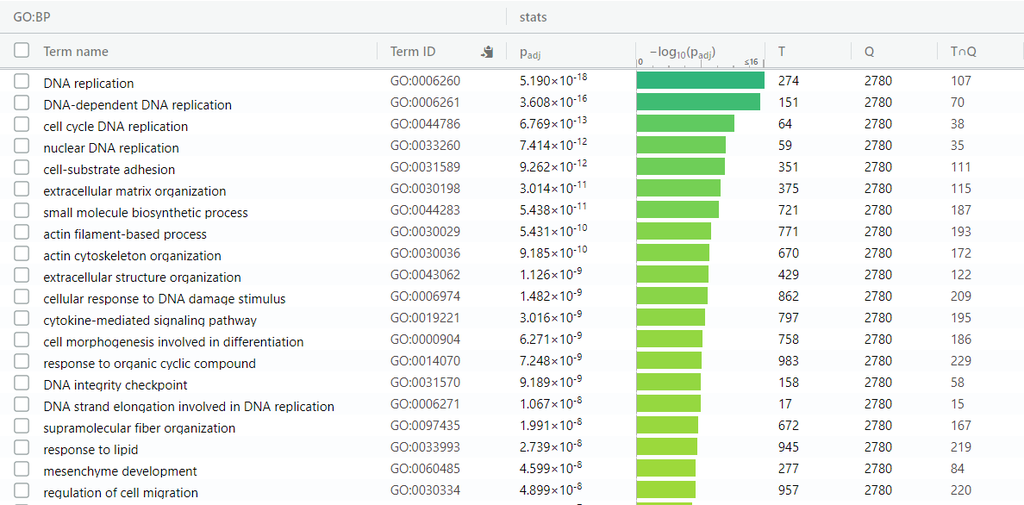

# Interpretation

**1. Do the over-representation results support conclusions or mechanisms discussed in the original paper?**

To summarize, I found that between uninfected human foreskin fibroblast (HFF) cells and HFFs infected with wild-type *T. gondii*, the genes that were upregulated in infected cells were most significantly enriched for annotations for DNA replication, DNA repair, and the cell cycle, while the downregulated genes in infected cells were most significantly enriched for annotations for cell adhesion, the extracellular matrix, and cytoskeletal organization.

How do these results compare to the study that the data originally came from (Matta et al. 2019)? As discussed in the “Introduction to Assignment 2” section of this notebook, the major findings of this study focused on comparisons involving IFN-B treatment and *T. gondii* parasites with a knockout for the TgIST gene. So, the authors do not report any results comparing the uninfected, untreated cells to the wild-type infected, untreated cells (i.e. the comparison performed in this assignment). In this assignment, I essentially compared the 2 conditions that the authors used as controls for their other 4 conditions. Most of the Matta et al. (2019) study is centered on the effects of IFN-B treatment and the knockout of TgIST rather than regular *T. gondii* infection, but neither of these experimental conditions are represented in my analyses here, so it is a bit hard to relate any of my findings here to those reported in this paper.

**2. Can you find evidence, i.e. publications, to support some of the results that you see? How does this evidence support your results?**

Despite this, I did manage to find support for some of my most significant gene annotations. In the study by Lie et al. (2019) that infected human retinal epithelial cells with *T. gondii*, the authors performed thresholded gene set enrichment analysis on the genes that were differentially-expressed due to infection. Using GO annotations showed a strong enrichment of immune-signaling genes, but using Reactome annotations, the authors found that the most significant pathways involved DNA replication and the cell cycle. Their 20 most significant Reactome pathways are shown in the figure below, which is Figure 6 from their paper (Lie et al. 2019).

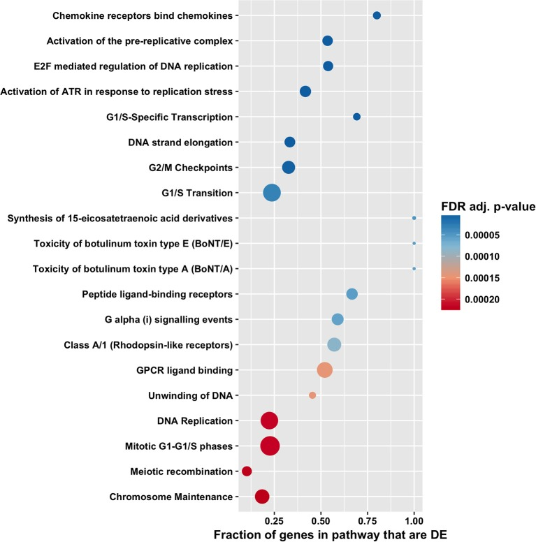

**(Figure 6 from Lie et al. (2019))**

# References

Davis, Sean, and Paul Meltzer. 2007. “GEOquery: A Bridge Between the Gene Expression Omnibus (Geo) and Bioconductor.” *Bioinformatics* 14: 1846–7.

Durinck, Steffen, Yves Moreau, Arek Kasprzyk, Sean Davis, Bart De Moor, Alvis Brazma, and Wolfgang Huber. 2005. “BioMart and Bioconductor: A Powerful Link Between Biological Databases and Microarray Data Analysis.” *Bioinformatics* 21: 3439–40.

Gu, Zuguang, Roland Eils, and Matthias Schlesner. 2016. “Complex Heatmaps Reveal Patterns and Correlations in Multidimensional Genomic Data.” *Bioinformatics*.

Lie, Shervi, Elise Rochet, Erik Segerdell, Yuefang Ma, Liam M. Ashander, Audra M. A. Shadforth, Timothy A. Blenkinsop, et al. 2019. “Immunological Molecular Responses of Human Retinal Pigment Epithelial Cells to Infection with Toxoplasma Gondii.” *Frontiers in Immunology* 10: 708.

Matta, Sumit K, Philipp Olias, Zhou Huang, Qiuling Wang, Eugene Park, Wayne M Yokoyama, and L David Sibley. 2019. “Toxoplasma Gondii Effector Tgist Blocks Type I Interferon Signaling to Promote Infection.” *Proceedings of the National Academy of Sciences* 116 (35): 17480–91.

McCarthy, Davis J, Yunshun Chen, and Gordon K Smyth. 2012. “Differential Expression Analysis of Multifactor Rna-Seq Experiments with Respect to Biological Variation.” *Nucleic Acids Research* 40 (10): 4288–97. https://doi.org/10.1093/nar/gks042.

Morgan, Martin. 2019. *BiocManager: Access the Bioconductor Project Package Repository*. https://CRAN.R-project.org/package=BiocManager.

Reimand, Jüri, Meelis Kull, Hedi Peterson, Jaanus Hansen, and Jaak Vilo. 2007. “G: Profiler—a Web-Based Toolset for Functional Profiling of Gene Lists from Large-Scale Experiments.” *Nucleic Acids Research* 35 (suppl_2): W193–W200.

Ritchie, Matthew E, Belinda Phipson, Di Wu, Yifang Hu, Charity W Law, Wei Shi, and Gordon K Smyth. 2015. “limma Powers Differential Expression Analyses for RNA-Sequencing and Microarray Studies.” *Nucleic Acids Research* 43 (7): e47. https://doi.org/10.1093/nar/gkv007.

Tanaka, Sachi, Maki Nishimura, Fumiaki Ihara, Junya Yamagishi, Yutaka Suzuki, and Yoshifumi Nishikawa. 2013. “Transcriptome Analysis of Mouse Brain Infected with Toxoplasma Gondii.” *Infection and Immunity* 81 (10): 3609–19.

Wickham, Hadley. 2016. *Ggplot2: Elegant Graphics for Data Analysis*. Springer-Verlag New York. https://ggplot2.tidyverse.org.

Xiao, Jianchun, Lorraine Jones-Brando, C Conover Talbot, and Robert H Yolken. 2011. “Differential Effects of Three Canonical Toxoplasma Strains on Gene Expression in Human Neuroepithelial Cells.” *Infection and Immunity* 79 (3): 1363–73.